# Changes in Sydney rent during covid 19

2020-07-03

Among the many things (ok, pretty much everything) that covid19 is impacting is the cost of rent in Sydney. The NSW government [releases the rent data monthly](https://www.fairtrading.nsw.gov.au/about-fair-trading/data-and-statistics/rental-bond-data) so I thought I’d take a look. This data comes from the rental bonds that must be submitted when new leases are signed, and show weekly rents. So a warning to you up-toppers, $500 weekly rent is $2166 per month.

The NSW Fair Trading data is for recent rental bond lodgements, so the number of new bonds should indicate the number of new leases signed. I’m not sure if a tenant resigning their lease at a different rent will appear in the rental bond data, or whether the previous bond is kept by the government as-is without any update to the data.

Here’s the changes in bonds lodged across greater Sydney. I was expecting a fall in bonds signed compared to last year as people tried not to move, but instead theres an increase — though as mentioned this maythe re-signing at lower rents.

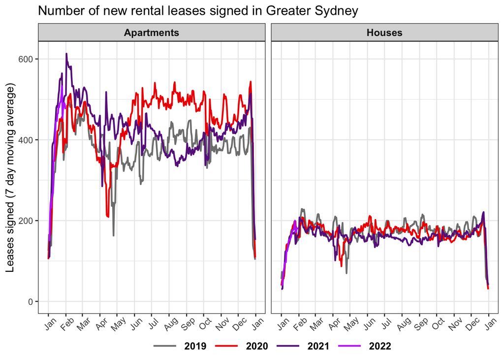

To look at average rents I split up housing into the largest categories, one and two bedroom apartments and three and four bedroom houses, and take a 7 day moving average.

Rents for apartments in greater Sydney have fallen by about 10% for 1 bedroom and 6.5% for 2 bedrooms.

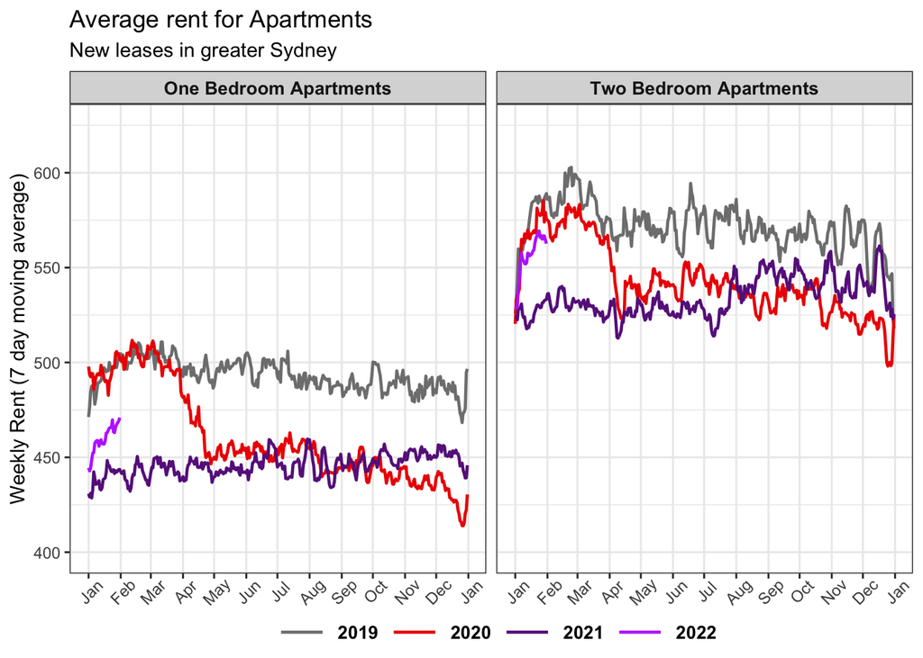

The fall in rent is slightly larger if I look within 5km of the University of Sydney, which includes the central business district and a lot of apartment stock.

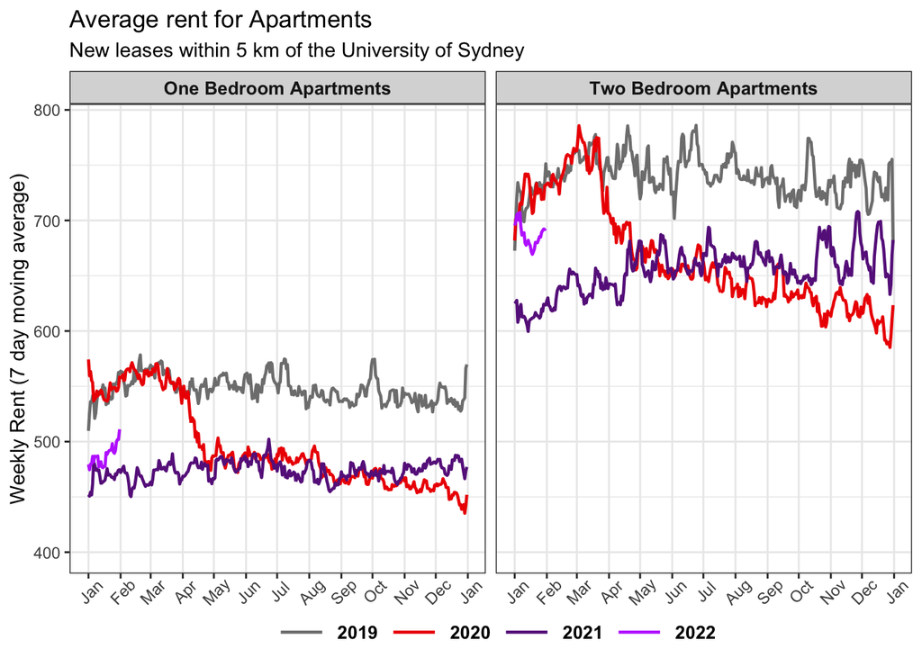

In contrast, rent for single-family dwellings (houses) hasn’t fallen at all. This suggests the impacts of the covid19 financial crisis are, unsurprisingly, being felt very differently depending on the type of housing you can afford.

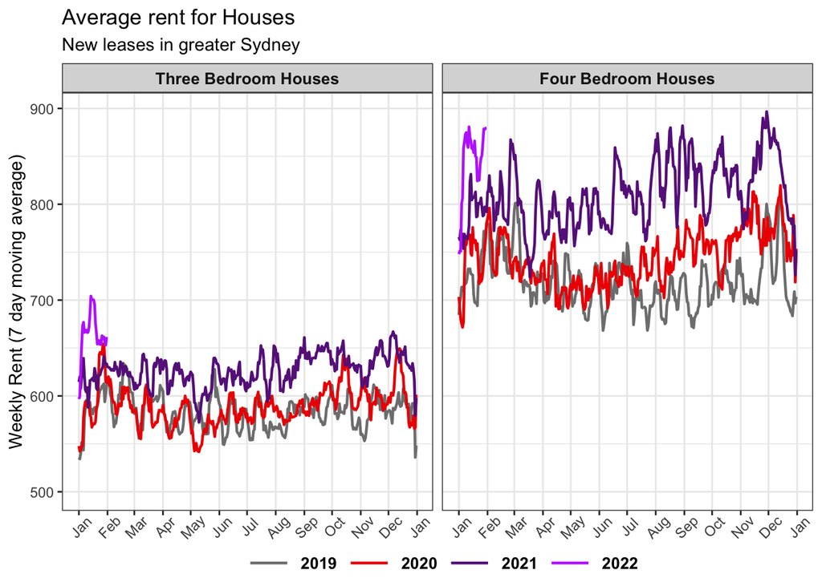

As the previous comparisons were for pandemic years and afterwards, I’ve plotted the full available time series of rents below.

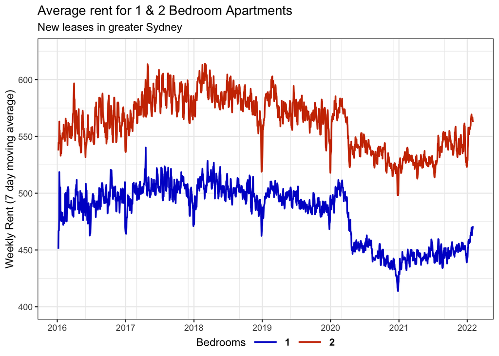

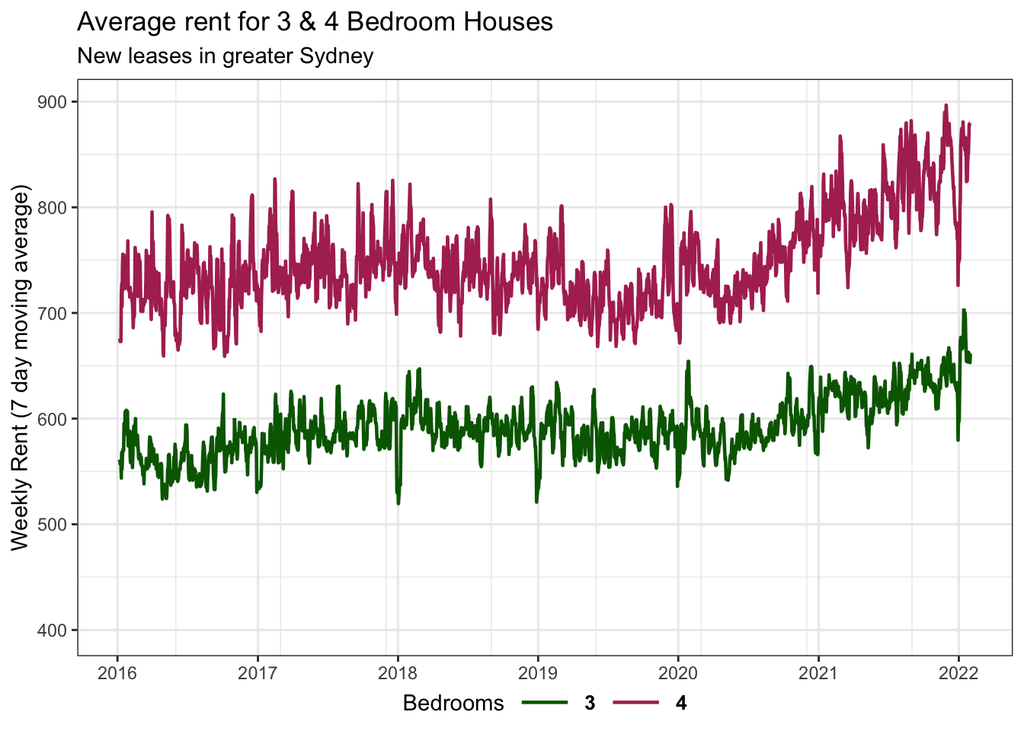